# ExtendedDataFig3A

Laurane Mangé

2025-03-13

## Introduction

This document produces pannel A from Extended Data Figure 3 from the lungNENomics manuscript, displaying the number of hallmarks of cancer (https://aacrjournals.org/cancerdiscovery/article/12/1/31/675608/Hallmarks-of-Cancer-New-DimensionsHallmarks-of) affected by damaging mutations per patient for each archetype. All file paths used are to be modified according to the user’s working directory.

## Libraries

The first step of the study is to load the required libraries.

```r
library(dplyr)
library(tidyverse)
```

```r
library(ggplot2)
library(ggpubr)
library(tidyr)
library(forestmodel)
library(rlang)
library(eulerr)
library(cowplot)
library(patchwork)
library(writexl)
library(jtools)
```

## Fetching the necessary data

We now load the necessary data for this study : Samples displaying genes with damaging SNV mutations, as well as archetypes for each sample and hallmarks of cancer affected through mutation for each gene.

```r
# dataframe with hallmarks from COSMIC
clean_hallmarks <- read_csv("/home/mangel/Hallmarks/Stage IARC/clean_hallmarks_COSMICv99_Intogen2023-05-31.tsv")
```

```
## ──────────────────────────────────────────────────────── Delimiter: "," chr
## (9): GENE_SYMBOL, COSMIC_GENE_ID, CELL_TYPE, SITE, PUBMED_PMID, HALLMARK... dbl
## (1): ...1 lgl (3): Hallmark_Cell2011, dup, in_both
```

```r
clean_hallmarks <- clean_hallmarks %>% dplyr::select(-c(1,11,12,13))

all_hm <- sort(unique(clean_hallmarks$HALLMARK))

# Pareto archetype color palette
arc4 <- c("Ca A1"="#999933", "Ca A2"="#DDCC77", "Ca B"="#117733", "sc-enriched"="#CC6677", "LCNEC"="#882255", "SCLC"="#332288")
### Hallmark profile colors
hmPalette <- c("#CC0000", "#006666", "#330066", "#CC2266", "#666666", "#003399", "#111111", "#336600", "#663333", "#CC6600")

# dataframe with damaging SNVs
snv_dmg <- get(load('dataset_snv_dmg_lungNENomicsCombined.RData'))
unique(snv_dmg$gene1_name)
```

[output not shown]

[output cut: 306 more lines]

```r
unique(snv_dmg$sample_id) #102 samples
```

```
##   [1] "LNEN067_TU"  "S00016"      "S01504_B_TU" "LNET5T"      "LNEN142_TU"
##   [6] "S01493"      "LNEN101_TU1" "LNEN055_TU"  "LNEN111_TU2" "LNEN113_TU2"
##  [11] "S02154"      "LNEN083_TU"  "LNEN068_TU"  "LNEN092_TU2" "S01529"
##  [16] "LNEN051_TU"  "LNEN100_TU1" "LNEN071_TU"  "LNEN116_TU1" "LNEN108_TU1"
##  [21] "S01528"      "S01746"      "LNEN047_TU"  "S01060_B_TU" "LNEN143_TU"
##  [26] "LNET10T"     "LNEN089_TU"  "LNET6T"      "LNEN094_TU5" "LNEN057_TU"
##  [31] "S01576"      "S01536"      "S01585"      "LNEN146_TU"  "LNEN093_TU2"
##  [36] "LNET2T"      "LNEN132_TU"  "LNEN095_TU2" "LNEN072_TU"  "S02334"
##  [41] "LNEN050_TU"  "LNEN052_TU"  "LNEN076_TU"  "LNEN074_TU"  "S01567"
##  [46] "LNEN126_TU"  "LNEN066_TU"  "LNEN107_TU2" "LNEN121_TU"  "LNEN134_TU"
##  [51] "LNEN114_TU2" "S01510"      "LNEN140_TU"  "S01502"      "LNEN081_TU"
##  [56] "LNEN048_TU"  "LNEN084_TU"  "S01742"      "LNEN064_TU"  "LNEN056_TU"
##  [61] "LNEN128_TU"  "LNEN125_TU"  "LNEN097_TU5" "LNEN123_TU"  "LNEN109_TU"
##  [66] "LNEN117_TU1" "LNEN145_TU"  "S01501"      "LNEN077_TU"  "LNEN079_TU"
##  [71] "LNEN098_TU1" "LNEN115_TU1" "S02333"      "S01539"      "S02327"
##  [76] "LNEN096_TU3" "LNEN133_TU"  "LNEN102_TU1" "S02325"      "S01733"
##  [81] "LNEN106_TU1" "LNEN104_TU3" "S01605_B_TU" "S02126"      "LNEN135_TU"
##  [86] "LNEN063_TU"  "LNEN136_TU"  "LNEN110_TU"  "LNEN130_TU"  "LNEN119_TU3"
##  [91] "LNEN118_TU2" "S01731"      "LNEN112_TU1" "S01526"      "S02330"
##  [96] "LNEN061_TU"  "LNEN139_TU"  "LNEN105_TU1" "S01513"      "LNEN060_TU"
## [101] "LNEN127_TU"  "S01538"
```

```r
dmg_genes_list <- unique(snv_dmg$gene1_name[which(snv_dmg$gene1_name %in% clean_hallmarks$GENE_SYMBOL)])
# 53 genes from clean_hallmarks (COSMIC)

# Making snv_dmg_arch : dataframe with damaging SNVs and archetypes per sample
variables_archetypes_MOFA_LNET <- get(load('variables_archetypes_MOFA_LNET.RData')) #319 samples

snv_dmg_arch <- get(load('variables_archetypes_MOFA_LNET.RData'))
snv_dmg_arch <- merge(snv_dmg_arch, snv_dmg[c('sample_id','gene1_name')], by = 'sample_id')
snv_dmg_arch <- snv_dmg_arch %>% relocate(gene1_name, .before=Factor1)
snv_dmg_arch <- snv_dmg_arch %>% relocate(archetype_k4_LF3_label, .before=Factor1)
snv_dmg_arch <- merge(snv_dmg_arch, clean_hallmarks[c('GENE_SYMBOL','HALLMARK')], by.x = 'gene1_name', by.y = 'GENE_SYMBOL',all=TRUE)
snv_dmg_arch <- snv_dmg_arch %>% relocate(HALLMARK, .before = Factor1)
snv_dmg_arch <- snv_dmg_arch %>% dplyr::filter(!is.na(sample_id))
snv_dmg_arch <- snv_dmg_arch %>% dplyr::filter(!duplicated(snv_dmg_arch))
snv_dmg_arch <- snv_dmg_arch %>% rename(archetype = archetype_k4_LF3_label)
unique(snv_dmg_arch$sample_id) # 102 good
```

```
##   [1] "LNEN067_TU"  "S00016"      "S01504_B_TU" "LNET5T"      "LNEN142_TU"
##   [6] "S01493"      "LNEN101_TU1" "LNEN055_TU"  "LNEN111_TU2" "LNEN113_TU2"
##  [11] "S02154"      "LNEN083_TU"  "LNEN051_TU"  "LNEN108_TU1" "S01528"
##  [16] "LNEN047_TU"  "S01060_B_TU" "LNET6T"      "LNEN057_TU"  "S01576"
##  [21] "S01536"      "S01585"      "LNEN071_TU"  "LNEN146_TU"  "LNET10T"
##  [26] "LNEN093_TU2" "LNET2T"      "LNEN132_TU"  "LNEN094_TU5" "LNEN095_TU2"
##  [31] "LNEN072_TU"  "S02334"      "LNEN050_TU"  "LNEN052_TU"  "LNEN076_TU"
##  [36] "LNEN100_TU1" "S01529"      "LNEN074_TU"  "S01567"      "LNEN066_TU"
##  [41] "LNEN092_TU2" "LNEN107_TU2" "LNEN121_TU"  "LNEN134_TU"  "LNEN114_TU2"
##  [46] "S01510"      "LNEN081_TU"  "LNEN048_TU"  "LNEN084_TU"  "S01742"
##  [51] "LNEN064_TU"  "LNEN116_TU1" "LNEN056_TU"  "LNEN128_TU"  "S01502"
##  [56] "LNEN125_TU"  "LNEN097_TU5" "LNEN123_TU"  "LNEN109_TU"  "LNEN117_TU1"
##  [61] "LNEN145_TU"  "S01501"      "LNEN089_TU"  "LNEN068_TU"  "LNEN077_TU"
##  [66] "LNEN079_TU"  "LNEN115_TU1" "LNEN098_TU1" "LNEN140_TU"  "S02333"
##  [71] "S01539"      "S02327"      "LNEN096_TU3" "LNEN133_TU"  "LNEN102_TU1"
##  [76] "S02325"      "S01733"      "LNEN106_TU1" "LNEN104_TU3" "S01605_B_TU"
##  [81] "S02126"      "LNEN135_TU"  "LNEN063_TU"  "LNEN136_TU"  "LNEN143_TU"
##  [86] "LNEN110_TU"  "S01746"      "LNEN130_TU"  "LNEN119_TU3" "LNEN118_TU2"
##  [91] "LNEN126_TU"  "S01731"      "LNEN112_TU1" "S01526"      "S02330"
##  [96] "LNEN061_TU"  "LNEN139_TU"  "LNEN105_TU1" "S01513"      "LNEN060_TU"
## [101] "LNEN127_TU"  "S01538"
```

```r
table(snv_dmg_arch$archetype)
```

```
##
##       Ca A1       Ca A2        Ca B sc-enriched
##         918         390         499         202
```

```r
unique(snv_dmg_arch %>% filter(!is.na(HALLMARK)) %>% pull(gene1_name)) # 53 dmg genes with hm affected
```

```
##  [1] "ARID1A"  "ATM"     "ATP1A1"  "ATR"     "ATRX"    "BCL11A"  "BRAF"
##  [8] "CAMTA1"  "CDH11"   "CDK12"   "CDKN1B"  "CREB3L1" "CRTC1"   "CTNNB1"
## [15] "DDR2"    "DDX5"    "EP300"   "ETNK1"   "FAT4"    "FOXL2"   "GNAS"
## [22] "KMT2A"   "KMT2C"   "KMT2D"   "KRAS"    "LRP1B"   "MAP3K1"  "MAPK1"
## [29] "MAX"     "MEN1"    "MTOR"    "MYC"     "NONO"    "NTRK3"   "PIK3CA"
## [36] "PMS2"    "POU5F1"  "PRDM1"   "PSIP1"   "PTEN"    "QKI"     "RUNX1T1"
## [43] "SETDB1"  "SF3B1"   "SMARCA4" "SMARCB1" "SPEN"    "SPOP"    "TET2"
## [50] "TGFBR2"  "TP53"    "XPO1"    "ZFHX3"
```

```r
table(snv_dmg_arch$HALLMARK)
```

```
##
##                       angiogenesis       cell replicative immortality
##                                 11                                 25
##      change of cellular energetics escaping immune response to cancer
##                                 15                                  7
##     escaping programmed cell death   genome instability and mutations
##                                 49                                 30
##            invasion and metastasis           proliferative signalling
##                                 53                                 37
##              suppression of growth      tumour promoting inflammation
##                                 35                                 14
```

There are 53 genes with damaging SNV mutations that affect at least one of the 10 known hallmarks of cancer.

We now create dataframes in “wide” format giving information about whether a hallmark is affected (1) or not (0) by the mutation of a given gene (first column).

```r
gene_hm.wide = snv_dmg_arch[c('gene1_name','HALLMARK')] %>% filter(!duplicated(snv_dmg_arch[c('gene1_name','HALLMARK')])) %>% mutate(Presence=1) %>%
  pivot_wider(id_cols = gene1_name, names_from = HALLMARK,values_from = Presence,values_fill = 0,names_expand = TRUE)

Missing <- setdiff(all_hm, names(gene_hm.wide[-1]))
gene_hm.wide[Missing] <- 0
gene_hm.wide <- gene_hm.wide[c('gene1_name',sort(colnames(gene_hm.wide[-1])))]
gene_hm.wide <- gene_hm.wide %>% select(-c("NA"))
```

We can make the same dataframe for archetypes instead of genes.

```r
arch_hm.wide = snv_dmg_arch[c('archetype','HALLMARK')] %>% filter(!duplicated(snv_dmg_arch[c('archetype','HALLMARK')])) %>% mutate(Presence=1) %>%
  pivot_wider(id_cols = archetype, names_from = HALLMARK,values_from = Presence,values_fill = 0,names_expand = TRUE)

Missing <- setdiff(all_hm, names(arch_hm.wide[-1]))
arch_hm.wide[Missing] <- 0
arch_hm.wide <- arch_hm.wide[c('archetype',sort(colnames(arch_hm.wide[-1])))]
arch_hm.wide <- arch_hm.wide %>% select(-c("NA"))
```

All 4 archetypes seem to have (almost) all hallmarks affected.

However, the dataframe in “wide” format we will use the most contains the previously mentioned hallmark information per sample (i.e. per patient).

```r
table(snv_dmg_arch$archetype,snv_dmg_arch$sample_id)
```

```
##
##               LNEN047_TU LNEN048_TU LNEN050_TU LNEN051_TU LNEN052_TU LNEN055_TU
##   Ca A1               15         19         13          0          0          0
##   Ca A2                0          0          0         25          0         14
##   Ca B                 0          0          0          0         25          0
##   sc-enriched          0          0          0          0          0          0
##
##               LNEN056_TU LNEN057_TU LNEN060_TU LNEN061_TU LNEN063_TU LNEN064_TU
##   Ca A1                0         20          0          0         29          0
##   Ca A2               21          0         13          9          0         29
##   Ca B                 0          0          0          0          0          0
##   sc-enriched          0          0          0          0          0          0
##
##               LNEN066_TU LNEN067_TU LNEN068_TU LNEN071_TU LNEN072_TU LNEN074_TU
##   Ca A1                0          0         32          0          0          0
##   Ca A2                0          0          0          0          0         21
##   Ca B                18         33          0          0          3          0
##   sc-enriched          0          0          0         84          0          0
##
##               LNEN076_TU LNEN077_TU LNEN079_TU LNEN081_TU LNEN083_TU LNEN084_TU
##   Ca A1               32          0          0         15          0          0
##   Ca A2                0         27          7          0          0          0
##   Ca B                 0          0          0          0         24          0
##   sc-enriched          0          0          0          0          0          8
##
##               LNEN089_TU LNEN092_TU2 LNEN093_TU2 LNEN094_TU5 LNEN095_TU2
##   Ca A1                0          42          19           0           0
##   Ca A2                0           0           0           0           0
##   Ca B                20           0           0          27          30
##   sc-enriched          0           0           0           0           0
##
##               LNEN096_TU3 LNEN097_TU5 LNEN098_TU1 LNEN100_TU1 LNEN101_TU1
##   Ca A1                 0          13           0          22           0
##   Ca A2                 5           0          16           0          12
##   Ca B                  0           0           0           0           0
##   sc-enriched           0           0           0           0           0
##
##               LNEN102_TU1 LNEN104_TU3 LNEN105_TU1 LNEN106_TU1 LNEN107_TU2
##   Ca A1                 0          19          32           0           0
##   Ca A2                11           0           0           0           0
```

[output cut: 47 more lines]

```
##   Ca A2            3      0     14      0      5      8      0      0      6
##   Ca B             0      0      0      0      0      0     14      0      0
##   sc-enriched      0      0      0      0      0      0      0      0      0
##
##               S01605_B_TU S01731 S01733 S01742 S01746 S02126 S02154 S02325
##   Ca A1                 0      0     11      6     10     12     21      0
##   Ca A2                21     12      0      0      0      0      0      0
##   Ca B                  0      0      0      0      0      0      0     20
##   sc-enriched           0      0      0      0      0      0      0      0
##
##               S02327 S02330 S02333 S02334
##   Ca A1           17     14     11      0
##   Ca A2            0      0      0     10
##   Ca B             0      0      0      0
##   sc-enriched      0      0      0      0
```

```r
length(unique(snv_dmg_arch$sample_id)) # 102 different samples
```

```
## [1] 102
```

```r
sample_hm.wide = snv_dmg_arch[c('sample_id','HALLMARK')] %>% filter(!duplicated(snv_dmg_arch[c('sample_id','HALLMARK')])) %>% mutate(Presence=1) %>%
  pivot_wider(id_cols = sample_id, names_from = HALLMARK,values_from = Presence,values_fill = 0,names_expand = TRUE)

Missing <- setdiff(all_hm, names(sample_hm.wide[-1]))
sample_hm.wide[Missing] <- 0
sample_hm.wide <- sample_hm.wide[c('sample_id',sort(colnames(sample_hm.wide[-1])))]

# samples belonging to each archetype
sc_samples <- unique(snv_dmg_arch %>% filter(archetype=="sc-enriched") %>% pull(sample_id))
a1_samples <- unique(snv_dmg_arch %>% filter(archetype=="Ca A1") %>% pull(sample_id))
a2_samples <- unique(snv_dmg_arch %>% filter(archetype=="Ca A2") %>% pull(sample_id))
b_samples <- unique(snv_dmg_arch %>% filter(archetype=="Ca B") %>% pull(sample_id))

### fisher tests on hallmarks within archetypes

fish_arch_hm  <- data.frame(matrix(nrow = 0, ncol = 4))
names(fish_arch_hm) <- c('archetype','hm','fisherTestPvalue','fisherTestOddsRatio')

for (i in 1:length(unique(snv_dmg_arch$archetype))) {
  for(j in 1:length(unique(snv_dmg_arch$HALLMARK)[-1])){
    fish_arch_hm[nrow(fish_arch_hm)+1, ] <- c(unique(snv_dmg_arch$archetype)[i],unique(snv_dmg_arch$HALLMARK)[j+1],round(fisher.test(table(snv_dmg_arch$archetype==unique(snv_dmg_arch$archetype)[i],snv_dmg_arch$HALLMARK==unique(snv_dmg_arch$HALLMARK)[j+1]))$p.value,3),round(fisher.test(table(snv_dmg_arch$archetype==unique(snv_dmg_arch$archetype)[i],snv_dmg_arch$HALLMARK==unique(snv_dmg_arch$HALLMARK)[j+1]))$estimate,3))
  }
}

fish_arch_hm
```

```
##      archetype                                 hm fisherTestPvalue
## 1         Ca B              suppression of growth            0.281
## 2         Ca B   genome instability and mutations            0.254
## 3         Ca B     escaping programmed cell death            0.851
## 4         Ca B       cell replicative immortality            0.802
## 5         Ca B            invasion and metastasis            0.713
## 6         Ca B      tumour promoting inflammation            0.201
## 7         Ca B      change of cellular energetics                1
## 8         Ca B           proliferative signalling            0.054
## 9         Ca B                       angiogenesis            0.465
## 10        Ca B escaping immune response to cancer                1
## 11       Ca A1              suppression of growth            0.584
## 12       Ca A1   genome instability and mutations            0.846
## 13       Ca A1     escaping programmed cell death            0.874
## 14       Ca A1       cell replicative immortality            0.835
```

[output cut: 67 more lines]

```r
fish_arch_hm[which(fish_arch_hm$fisherTestPvalue<=0.05),]
```

```
##    archetype                    hm fisherTestPvalue fisherTestOddsRatio
## 19     Ca A1          angiogenesis            0.011               6.401
## 21     Ca A2 suppression of growth            0.025               2.495
```

```r
# signif : Ca A1 angiogenesis more than expected and Ca A2 suppression of growth same
```

Now we plot the distribution of the number of hallmarks affected per patients for each archetype in the form of a violin plot.

```r
sample_hm_arch.wide <- merge(sample_hm.wide,snv_dmg_arch[c("sample_id","archetype")],by="sample_id")
sample_hm_arch.wide <- sample_hm_arch.wide %>% filter(!duplicated(sample_hm_arch.wide))

sample_sizes <- as.data.frame(cbind(unique(sample_hm_arch.wide$archetype),c(length(a1_samples),length(a2_samples),length(b_samples),length(sc_samples))))
colnames(sample_sizes) <- c("archetype","n")
sample_sizes$n <- as.numeric(sample_sizes$n)

wilcox.test(rowSums(sample_hm_arch.wide %>% filter(archetype=="Ca A1") %>% select(-c(1,9,13))),rowSums(sample_hm_arch.wide %>% filter(archetype=="Ca A2") %>% select(-c(1,9,13))),paired=FALSE)
```

```
##
##  Wilcoxon rank sum test with continuity correction
##
## data:  rowSums(sample_hm_arch.wide %>% filter(archetype == "Ca A1") %>% select(-c(1, 9, 13))) and rowSums(sample_hm_arch.wide %>% filter(archetype == "Ca A2") %>% select(-c(1, 9, 13)))
## W = 643, p-value = 0.9554
## alternative hypothesis: true location shift is not equal to 0
```

```r
wilcox.test(rowSums(sample_hm_arch.wide %>% filter(archetype=="Ca A1") %>% select(-c(1,9,13))),rowSums(sample_hm_arch.wide %>% filter(archetype=="Ca B") %>% select(-c(1,9,13))),paired=FALSE)
```

```
##
##  Wilcoxon rank sum test with continuity correction
##
## data:  rowSums(sample_hm_arch.wide %>% filter(archetype == "Ca A1") %>% select(-c(1, 9, 13))) and rowSums(sample_hm_arch.wide %>% filter(archetype == "Ca B") %>% select(-c(1, 9, 13)))
## W = 485.5, p-value = 0.5588
## alternative hypothesis: true location shift is not equal to 0
```

```r
wilcox.test(rowSums(sample_hm_arch.wide %>% filter(archetype=="Ca A1") %>% select(-c(1,9,13))),rowSums(sample_hm_arch.wide %>% filter(archetype=="sc-enriched") %>% select(-c(1,9,13))),paired=FALSE)
```

```
##
##  Wilcoxon rank sum test with continuity correction
##
## data:  rowSums(sample_hm_arch.wide %>% filter(archetype == "Ca A1") %>% select(-c(1, 9, 13))) and rowSums(sample_hm_arch.wide %>% filter(archetype == "sc-enriched") %>% select(-c(1, 9, 13)))
## W = 39.5, p-value = 0.01297
## alternative hypothesis: true location shift is not equal to 0
```

```r
wilcox.test(rowSums(sample_hm_arch.wide %>% filter(archetype=="Ca A2") %>% select(-c(1,9,13))),rowSums(sample_hm_arch.wide %>% filter(archetype=="Ca B") %>% select(-c(1,9,13))),paired=FALSE)
```

```
##
##  Wilcoxon rank sum test with continuity correction
##
## data:  rowSums(sample_hm_arch.wide %>% filter(archetype == "Ca A2") %>% select(-c(1, 9, 13))) and rowSums(sample_hm_arch.wide %>% filter(archetype == "Ca B") %>% select(-c(1, 9, 13)))
## W = 314.5, p-value = 0.5257
## alternative hypothesis: true location shift is not equal to 0
```

```r
wilcox.test(rowSums(sample_hm_arch.wide %>% filter(archetype=="Ca A2") %>% select(-c(1,9,13))),rowSums(sample_hm_arch.wide %>% filter(archetype=="sc-enriched") %>% select(-c(1,9,13))),paired=FALSE)
```

```
##
##  Wilcoxon rank sum test with continuity correction
##
## data:  rowSums(sample_hm_arch.wide %>% filter(archetype == "Ca A2") %>% select(-c(1, 9, 13))) and rowSums(sample_hm_arch.wide %>% filter(archetype == "sc-enriched") %>% select(-c(1, 9, 13)))
## W = 20, p-value = 0.007396
## alternative hypothesis: true location shift is not equal to 0
```

```r
wilcox.test(rowSums(sample_hm_arch.wide %>% filter(archetype=="Ca B") %>% select(-c(1,9,13))),rowSums(sample_hm_arch.wide %>% filter(archetype=="sc-enriched") %>% select(-c(1,9,13))),paired=FALSE)
```

```
##
##  Wilcoxon rank sum test with continuity correction
##
## data:  rowSums(sample_hm_arch.wide %>% filter(archetype == "Ca B") %>% select(-c(1, 9, 13))) and rowSums(sample_hm_arch.wide %>% filter(archetype == "sc-enriched") %>% select(-c(1, 9, 13)))
## W = 20.5, p-value = 0.02004
## alternative hypothesis: true location shift is not equal to 0
```

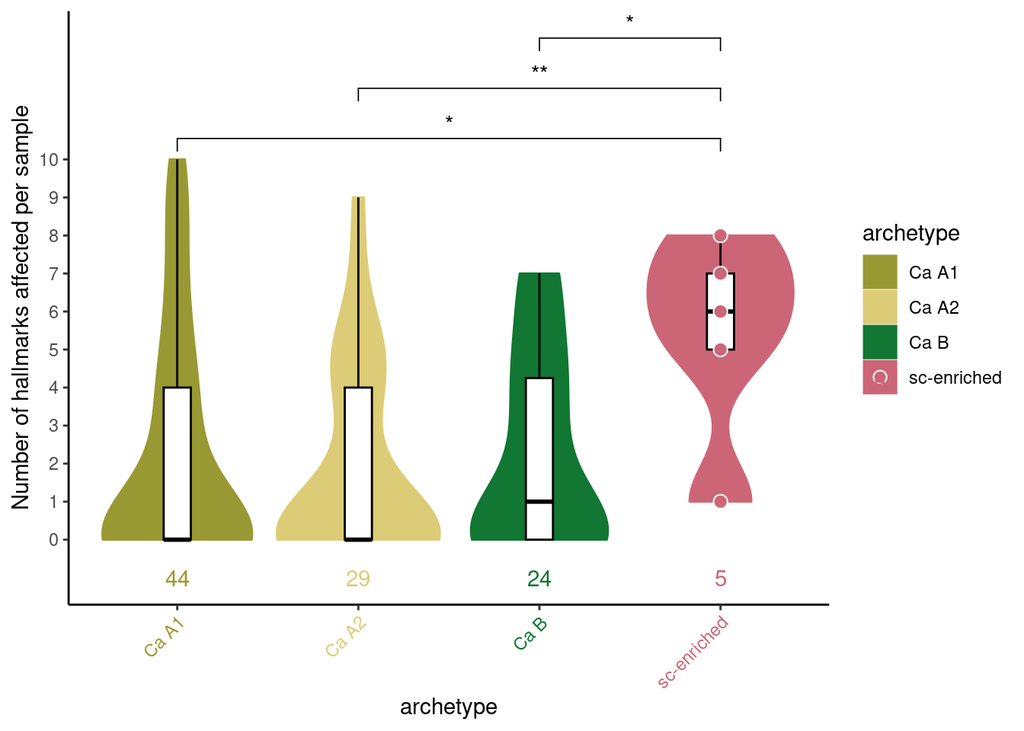

```r
# sc-enriched diff with every other group

#my_comparisons <- list( c("Ca A1", "Ca A2"), c("Ca A1", "Ca B"), c("Ca A1", "sc-enriched"), c("Ca A2", "Ca B"), c("Ca A2", "sc-enriched"), c("Ca B", "sc-enriched"))
my_comparisons <- list(c("Ca A1", "sc-enriched"), c("Ca A2", "sc-enriched"), c("Ca B", "sc-enriched"))
#only these are significant

violin <- ggplot(sample_hm_arch.wide, aes(x=archetype, y=rowSums(sample_hm_arch.wide[,c(2:8,10:12)]), fill=archetype, color=archetype)) +
  geom_violin() +
  geom_boxplot(width=0.15, color="black", fill="white") +
  geom_dotplot(data=sample_hm_arch.wide %>% filter(archetype=="sc-enriched"),aes(x=archetype,y=rowSums(sample_hm_arch.wide %>% filter(archetype=="sc-enriched") %>% select(c(2:8,10:12)))), binaxis = "y", stackdir='center', color="white") +
  scale_color_manual(values=arc4) +
  scale_fill_manual(values=arc4) +
  scale_y_continuous(breaks = seq(0, 10, by = 1)) +
  labs(y="Number of hallmarks affected per sample") +
  geom_text(data = sample_sizes,aes(x=archetype,y=-1,label=n)) +
  theme_bw() +
  theme(panel.grid=element_blank(), panel.border = element_blank(), panel.background = element_blank(), axis.line = element_line(colour = "black")) +
  theme(axis.text.x = element_text(angle = 45, hjust=1,colour =arc4[(c("Ca A1","Ca A2","Ca B","sc-enriched"))]))
violin <- violin + stat_compare_means(comparisons = my_comparisons, method = "wilcox.test", label = "p.signif")
violin
```